# Google Data Analytics Capstone Project Cyclistic Bike Share Co.

Nicholas Moore

2022-07-02

**Background** The following case study was provided by Coursera’s Google Data Analytics course. Analysts are to follow to the steps of the data analysis process (ask, prepare, process, analyze, share,and act) for a dataset that represents a fictional company (Cyclistic Bike-Share). Public data for this study was provided by [Motivate International Inc.](https://divvy-tripdata.s3.amazonaws.com/index.html) under this [Licence](https://ride.divvybikes.com/data-license-agreement). Results are not guaranteed to be perfect as I am still a novice. Feel free to follow along with my code chunks if you are stuck! Good luck and have fun!! :)

## PHASE 1 - ASK

**What topic are you exploring?** In this case study, I will explore Cyclistic’s bike-sharing company to compare usage data of casual riders versus annual members with the aim of uncovering insights and providing recommendations on how to turn casual riders to paying members.

**What is the problem you are trying to solve?** The issue on hand is how to maximize ridership by converting casual riders to annual paying members. This includes identifying marketing strategies including marketing channels that casual riders may be most receptive to. The company’s director of marketing believes that the company’s long-term viability rests on this endeavor.

**Specific task:** Determine how annual members and casual riders use Cyclistic bikes differently.

**What metrics will you use to measure your data to achieve your objective? Who are the stakeholders?**

**Are there issues with bias or credibility in this data? Does your data ROCCC?** Yes!

**R**eliable - Despite the absence of station identities in about 25% of the transactions, overall, data remains reliable as coordinates are present throughout all transactions. If need be, station names and IDs could be identified using station coordinate values.

**O**riginal - Data is proprietary to Cyclistic.Data is coming from the original source.

**C**omprehensive - We are primarily looking at 2021-022 data, but record goes back to 2013. In 2021 alone, there were 5.55M transactions–giving us a wealth of data to work with and possibly provide accurate results even with a sample size.

**C**urrent - The data remains current and valid to come up with plausible recommendations given almost similar circumstances between 2021 and 2022 in terms of mobility and economic behavior amid the pandemic.

**C**ited - As mentioned, we are working with first-party data generated from Cyclistic’s bike-sharing technology.

**How are you addressing licensing, privacy, security, and accessibility?** The data downloaded will be stored in my local drive and the original data will remain on the company website. Raw data will not be shared by any means and processed data will only be displayed as tables, tibbles and visualization—keeping the raw data inaccessible to the public.

**How did you verify the data’s integrity?** The data variables for each monthly dataset were compared and confirmed to be identical. Also, all nulls were removed from the final mutated dataset. Since the data comes directly from the company, the data is considered reliable and unaltered to be biased.

**How does it help you answer your question?** In order to create a singular dataset, each of the column variable types throughout all individual data files will have to match. Removing nulls will also remove possible inconsistencies with my results.

**Are there any problems with the data?** The data appears to have been primarily cleaned with the exception of some transactions having missing data. Rows will have to be omitted with missing data. Also, a plethora of ride duration values appear to be very short (less than 10 seconds). This are likely not representative of a normal ride and they will be excluded.

## PHASE 2 & 3 - PREPARE & PROCESS

**The following steps were used to clean and manipulate the data:**

**Began by installing and loading packages**

```r
#Essential library kits
library(pacman)
library(geosphere)
library(xlsx)
library(magrittr)
library(ggpol)
library(lubridate)
library(janitor)
library(dplyr)
library(GGally)
library(ggplot2)
library(ggthemes)
library(rmarkdown)
library(shiny)
library(stringr)
library(tidyr)
library(skimr)
library(scales)
library(reshape2)
library(ggthemes)
```

**Setting my directory so I could import the data into R**

```r
#I had to manually flip all of the dashes
setwd('C:/Users/Siggi/Downloads/BikeShareGit')
```

**Importing case study data**

```r
#Importing and renaming the csv files
April2021 <- read.csv('202103_Apr_21.csv')
May2021 <- read.csv('202104_May_21.csv')
June2021 <- read.csv('202105_Jun_21.csv')
July2021 <- read.csv('202106_Jul_21.csv')
August2021 <- read.csv('202107_Aug_21.csv')
September021 <- read.csv('202108_Sep_21.csv')
October2021 <- read.csv('202109_Oct_21.csv')
November2021 <- read.csv('202110_Nov_21.csv')
December2021 <- read.csv('202111_Dec_21.csv')
January2022 <- read.csv('202112_Jan_22.csv')
February2022 <- read.csv('202201_Feb_22.csv')
March2022 <- read.csv('202202_Mar_22.csv')
```

**Binding each dataset into one single dataset. They all have identical columns with shared data types so binding will work.**

```r
bike_data <- bind_rows(April2021, May2021, June2021, July2021, August2021, September021, October2021, November2021, December2021, January2022, February2022, March2022)

head(bike_data)
```

```
##            ride_id rideable_type          started_at            ended_at
## 1 CFA86D4455AA1030  classic_bike 2021-03-16 08:32:30 2021-03-16 08:36:34
## 2 30D9DC61227D1AF3  classic_bike 2021-03-28 01:26:28 2021-03-28 01:36:55
## 3 846D87A15682A284  classic_bike 2021-03-11 21:17:29 2021-03-11 21:33:53
## 4 994D05AA75A168F2  classic_bike 2021-03-11 13:26:42 2021-03-11 13:55:41
## 5 DF7464FBE92D8308  classic_bike 2021-03-21 09:09:37 2021-03-21 09:27:33
## 6 CEBA8516FD17F8D8  classic_bike 2021-03-20 11:08:47 2021-03-20 11:29:39
##             start_station_name start_station_id
## 1 Humboldt Blvd & Armitage Ave            15651
## 2 Humboldt Blvd & Armitage Ave            15651
## 3        Shields Ave & 28th Pl            15443
## 4  Winthrop Ave & Lawrence Ave     TA1308000021
## 5     Glenwood Ave & Touhy Ave              525
## 6     Glenwood Ave & Touhy Ave              525
##                      end_station_name end_station_id start_lat start_lng
## 1             Stave St & Armitage Ave          13266  41.91751 -87.70181
## 2 Central Park Ave & Bloomingdale Ave          18017  41.91751 -87.70181
## 3                Halsted St & 35th St   TA1308000043  41.84273 -87.63549
## 4              Broadway & Sheridan Rd          13323  41.96881 -87.65766
## 5           Chicago Ave & Sheridan Rd           E008  42.01270 -87.66606
## 6           Chicago Ave & Sheridan Rd           E008  42.01270 -87.66606
##    end_lat   end_lng member_casual
## 1 41.91774 -87.69139        casual
## 2 41.91417 -87.71676        casual
## 3 41.83066 -87.64717        casual
## 4 41.95283 -87.64999        casual
## 5 42.05049 -87.67782        casual
## 6 42.05049 -87.67782        casual
```

**Adding a new column**

```r
#Making a new weekday column WITHOUT the time included
bike_data$weekday <- as.Date(bike_data$started_at)
```

**I added more manipulated columns to the dataset:** Ride duration (in minutes), month of the year, day of the week, hour of day

```r
bike_data_v2<- bike_data %>%
  mutate(ride_duration = as.numeric(difftime(ended_at, started_at, unit="mins"))) %>%
  mutate(ride_duration_hours = as.numeric(difftime(ended_at, started_at, unit="hours"))) %>%
  mutate(ride_distance = distHaversine(cbind(start_lng, start_lat), cbind(end_lng, end_lat))) %>%
  mutate(ride_year = year(started_at)) %>%
  mutate(ride_month = month(started_at, label = TRUE)) %>%
  mutate(day_of_week = weekdays(weekday)) %>%
  mutate(hour_of_day = hour(started_at))
```

```r
#to calculate number of NA values
sum(is.na(bike_data_v2))
```

```
## [1] 13851
```

```r
#checking that NA values are now zero
sum(is.na(bike_data_v3))
```

[output not shown]

```
## [1] 0
```

#this got rid of pesky empty cells in station columns

```r
bike_data_v3 <- with(bike_data_v3, bike_data_v3[!(start_station_id == "" | is.na(start_station_id)), ])
bike_data_v3 <- with(bike_data_v3, bike_data_v3[!(end_station_id == "" | is.na(end_station_id)), ])
```

**THIS IS HOW TO DELETE ROWS WITH CONDITIONS** I deleted numeric values in a numeric column under 15 seconds (.25 minutes). This is because these are likely not “real” representations of rikes.

```r
bike_data_v4 <- bike_data_v3[!(bike_data_v3$ride_duration<0.25),]
skim(bike_data_v4)
```

Data summary

| Name | bike_data_v4 |
| --- | --- |
| Number of rows | 4610038 |
| Number of columns | 21 |
| _______________________ |  |
| Column type frequency: |  |
| character | 10 |
| Date | 1 |
| factor | 1 |
| numeric | 9 |
| ________________________ |  |
| Group variables | None |

**Variable type: character**

| skim_variable | n_missing | complete_rate | min | max | empty | n_unique | whitespace |
| --- | --- | --- | --- | --- | --- | --- | --- |
| ride_id | 0 | 1 | 16 | 16 | 0 | 4610038 | 0 |
| rideable_type | 0 | 1 | 11 | 13 | 0 | 3 | 0 |
| started_at | 0 | 1 | 19 | 19 | 0 | 3958803 | 0 |
| ended_at | 0 | 1 | 19 | 19 | 0 | 3951472 | 0 |
| start_station_name | 0 | 1 | 0 | 53 | 1 | 848 | 0 |
| start_station_id | 0 | 1 | 3 | 44 | 0 | 838 | 0 |
| end_station_name | 0 | 1 | 10 | 53 | 0 | 844 | 0 |
| end_station_id | 0 | 1 | 3 | 44 | 0 | 836 | 0 |
| member_casual | 0 | 1 | 6 | 6 | 0 | 2 | 0 |
| day_of_week | 0 | 1 | 6 | 9 | 0 | 7 | 0 |

**Variable type: Date**

| skim_variable | n_missing | complete_rate | min | max | median | n_unique |
| --- | --- | --- | --- | --- | --- | --- |
| weekday | 0 | 1 | 2021-03-01 | 2022-02-28 | 2021-08-03 | 365 |

**Variable type: factor**

| skim_variable | n_missing | complete_rate | ordered | n_unique | top_counts |
| --- | --- | --- | --- | --- | --- |
| ride_month | 0 | 1 | TRUE | 12 | Jul: 689188, Aug: 671452, Sep: 618402, Jun: 605939 |

**Variable type: numeric**

| skim_variable | n_missing | complete_rate | mean | sd | p0 | p25 | p50 | p75 | p100 | hist |
| --- | --- | --- | --- | --- | --- | --- | --- | --- | --- | --- |
| start_lat | 0 | 1 | 41.90 | 0.04 | 41.65 | 41.88 | 41.90 | 41.93 | 45.64 | ▇▁▁▁▁ |
| start_lng | 0 | 1 | -87.64 | 0.02 | -87.83 | -87.66 | -87.64 | -87.63 | -73.80 | ▇▁▁▁▁ |
| end_lat | 0 | 1 | 41.90 | 0.04 | 41.65 | 41.88 | 41.90 | 41.93 | 42.17 | ▁▁▇▁▁ |
| end_lng | 0 | 1 | -87.64 | 0.02 | -87.83 | -87.66 | -87.64 | -87.63 | -87.52 | ▁▁▆▇▁ |
| ride_duration | 0 | 1 | 21.72 | 183.70 | 0.25 | 6.93 | 12.13 | 21.98 | 55944.15 | ▇▁▁▁▁ |
| ride_duration_hours | 0 | 1 | 0.36 | 3.06 | 0.00 | 0.12 | 0.20 | 0.37 | 932.40 | ▇▁▁▁▁ |
| ride_distance | 0 | 1 | 2131.98 | 1955.52 | 0.00 | 908.34 | 1619.49 | 2809.92 | 1190854.54 | ▇▁▁▁▁ |
| ride_year | 0 | 1 | 2021.04 | 0.19 | 2021.00 | 2021.00 | 2021.00 | 2021.00 | 2022.00 | ▇▁▁▁▁ |
| hour_of_day | 0 | 1 | 14.24 | 5.01 | 0.00 | 11.00 | 15.00 | 18.00 | 23.00 | ▁▃▅▇▃ |

**I did not delete the ride_distance of 0 because those could have been people who left and returned to the same station**

## PHASE 4 & 5 - ANALYZE & SHARE

```r
#I run this before making my graph. This will prevent the y-axis from showing scientific notation numbers
options(scipen=5)
```

#applying the font type I would like for my figures

```r
windowsFonts(A = windowsFont("Times New Roman"))
```

**FIGURE 1:** Bar graph for casual vs. member weekday ride amounts

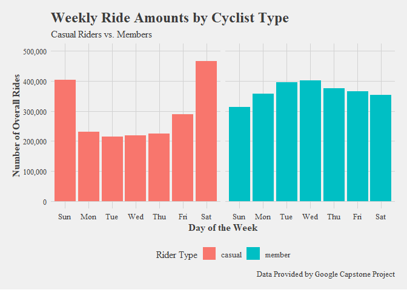

```r
ggplot(data=bike_data_v4)+
  geom_bar(mapping = aes(x=day_of_week,fill=member_casual))+
  scale_x_discrete(limits = c("Sunday","Monday","Tuesday","Wednesday","Thursday","Friday","Saturday"),
                   labels = c("Sun","Mon","Tue","Wed","Thu","Fri","Sat"))+ #the discrete lines show how I rearranges the x-axis labels to go from sun-sat and be renamed to shorter text
  facet_wrap(~member_casual)+
  theme(strip.text = element_blank())+
  labs(title="Weekly Ride Amounts by Cyclist Type", subtitle="Casual Riders vs. Members",
       x = "Day of the Week",
       y = "Number of Overall Rides",
       caption="Data Provided by Google Capstone Project")+
  scale_y_continuous(limits=c(0,500000), labels = scales::comma)+ #this combined scale_y_continuous(limits=c(0,500000)  AND scale_y_continuous(labels=comma)
  theme_fivethirtyeight(base_size = 12, base_family = "A")+
  labs(fill='Rider Type')+
  theme(axis.title = element_text(face="bold"), strip.text = element_blank())
```

**FIGURE 2:** Bar graph for casual vs. member monthly ride amounts

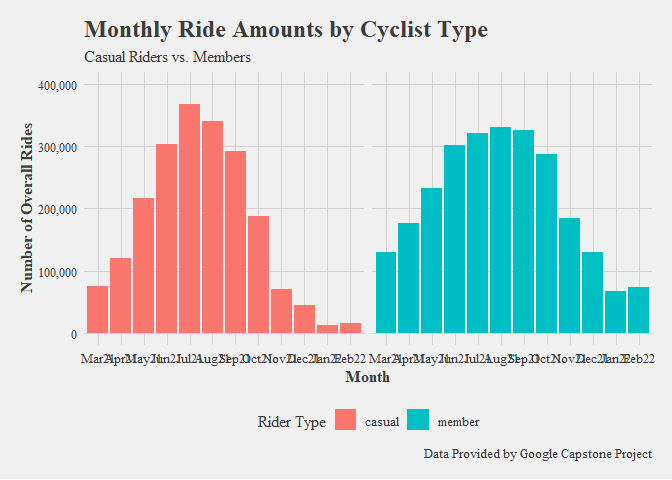

```r
ggplot(data=bike_data_v4)+
  geom_bar(mapping = aes(x=ride_month,fill=member_casual))+
  scale_x_discrete(limits = c("Mar","Apr","May","Jun","Jul","Aug","Sep", "Oct", "Nov", "Dec", "Jan", "Feb"),
                   labels = c("Mar21","Apr21","May21","Jun21","Jul21","Aug21","Sep21", "Oct21", "Nov21", "Dec21", "Jan22", "Feb22"))+ #the discrete lines show how I rearranges the x-axis labels to go from sun-sat and be renamed to shorter text
  facet_wrap(~member_casual)+
  theme(strip.text = element_blank())+
  labs(title="Monthly Ride Amounts by Cyclist Type", subtitle="Casual Riders vs. Members",
       x = "Month",
       y = "Number of Overall Rides",
       caption="Data Provided by Google Capstone Project")+
  scale_y_continuous(limits=c(0,400000), labels = scales::comma)+ #this combined scale_y_continuous(limits=c(0,500000)  AND scale_y_continuous(labels=comma)
  theme_fivethirtyeight(base_size = 12, base_family = "A")+
  labs(fill='Rider Type')+
  theme(axis.title = element_text(face="bold"), strip.text = element_blank())
```

**FIGURE 3:** Average ride duration for members vs casual riders

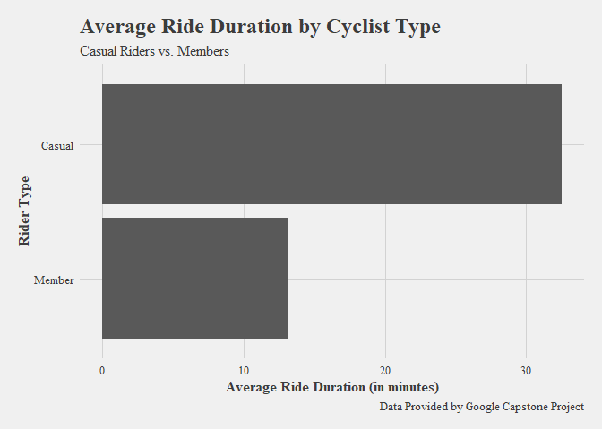

```r
ggplot(data=bike_data_v4, aes(x = member_casual, y = ride_duration)) +
  stat_summary(geom = "bar", fun.y = "mean")+
  coord_flip()+
  scale_x_discrete(limits = c("member","casual"),
                   labels = c("Member", "Casual"))+
  labs(title="Average Ride Duration by Cyclist Type", subtitle="Casual Riders vs. Members",
       x = "Rider Type",
       y = "Average Ride Duration (in minutes)",
       caption="Data Provided by Google Capstone Project")+
  theme_fivethirtyeight(base_size = 12, base_family = "A")+
  theme(axis.title = element_text(face="bold"), strip.text = element_blank())
```

**Prepping for Figure 4**

```r
#removing columns that are unnecessary for graph
bike_data_removedcols <- select(bike_data_v4, -c(ride_id:end_lng, weekday, ride_distance, ride_year, day_of_week, hour_of_day, ride_duration))
```

```r
#grouping the y and x axis's & then putting the sum of ride_duration next to those two groupings
bike_data_removedcols_V2 <- bike_data_removedcols %>%
  group_by(member_casual, ride_month) %>%
  summarise(ride_duration_sum=sum(ride_duration_hours))
```

**FIGURE 4:** Total Monthly Ride Times By Cyclist Type

[figure not shown]

```r
#yay done
ggplot(data = bike_data_removedcols_V2, aes(ride_month, ride_duration_sum, fill=member_casual, group = member_casual))+
  geom_col(position = position_dodge())+
  scale_x_discrete(limits = c("Apr","May","Jun","Jul","Aug","Sep","Oct", "Nov","Dec","Jan","Feb","Mar"),
                   labels = c("Apr21","May21","Jun21","Jul21","Aug21","Sep21","Oct21", "Nov21","Dec21","Jan22","Feb22","Mar22"))+
  theme(strip.text = element_blank())+
  labs(title="Total Monthly Ride Durations by Cyclist Type", subtitle="April 2021 - March 2022",
       x = "Month & Year",
       y = "Overall Ride Duration (in hours)",
       caption="Data Provided by Google Capstone Project")+
  scale_y_continuous(breaks = c(0,40000,80000,120000,160000,200000), labels = scales::comma)+ #this combined scale_y_continuous(limits=c(0,500000)  AND scale_y_continuous(labels=comma)
  theme_fivethirtyeight(base_size = 12, base_family = "A")+
  labs(fill='Rider Type')+
  theme(axis.title = element_text(face="bold"), strip.text = element_blank())
```

**FIGURE 5:** Monthly Ride Counts by Cyclist Type

[figure not shown]

```r
ggplot(data=bike_data_v4)+
  geom_bar(mapping = aes(x = ride_month, fill = member_casual))+
  scale_x_discrete(limits = c("Apr","May","Jun","Jul","Aug","Sep","Oct", "Nov","Dec","Jan","Feb","Mar"),
                   labels = c("Apr21","May21","Jun21","Jul21","Aug21","Sep21","Oct21", "Nov21","Dec21","Jan22","Feb22","Mar22"))+
  theme(strip.text = element_blank())+
  labs(title="Monthly Ride Amounts by Cyclist Type", subtitle="April 2021 - March 2022",
       x = "Month",
       y = "Number of Overall Rides",
       caption="Data Provided by Google Capstone Project")+
  scale_y_continuous(breaks = c(0,100000, 200000, 300000, 400000, 500000, 600000, 700000), labels = scales::comma)+ #this combined scale_y_continuous(limits=c(0,500000)  AND scale_y_continuous(labels=comma)
  theme_fivethirtyeight(base_size = 12, base_family = "A")+
  labs(fill='Rider Type')+
  theme(axis.title = element_text(face="bold"), strip.text = element_blank())
```

## PHASE 6 - ACT

**Key takeaways and recommendations based upon the insights gained from data analyses:**

**Recommendations:**

1. Increase marketing strategies between peak usage months.
- Offer a discount to friends which allows them to have their first ride free.
2. Consider seasonal membership specials or exclusive discounts to encourage casual riders transition into members.
3. Send promotions which demonstrate how much money can be saved when becoming a member.
4. Offer unique annual plans which discounts based on personal bike usage
- Allow an option to get an annual pass with a summer/winter discount.
- Automatic discount for the top two months when ride duration is lowest.
- Discount when reaching a total number of miles or hours in a month.